# Aplicação prática: estruturas e padrões

Material complementar - A4

# Objetivo

Este material exemplifica, em **R**, como comparar PCA, Kernel PCA, projeções aleatórias e três abordagens de agrupamento (k-médias, hierárquico e espectral) na investigação de estruturas multivariadas.

O roteiro é:

$$\text{dados} \longrightarrow \text{exploração} \longrightarrow \text{PCA} \longrightarrow \text{Kernel PCA} \longrightarrow \text{projeção aleatória} \longrightarrow \text{agrupamento} \longrightarrow \text{interpretação}$$

# Pacotes

```r
library(ggplot2)
library(dplyr)
library(tidyr)
library(kernlab)
library(patchwork)
```

# Base simulada: uma estrutura curva

Simularemos duas coordenadas informativas sobre uma curva não linear e oito variáveis adicionais, algumas correlacionadas com as coordenadas originais e outras constituídas por ruído.

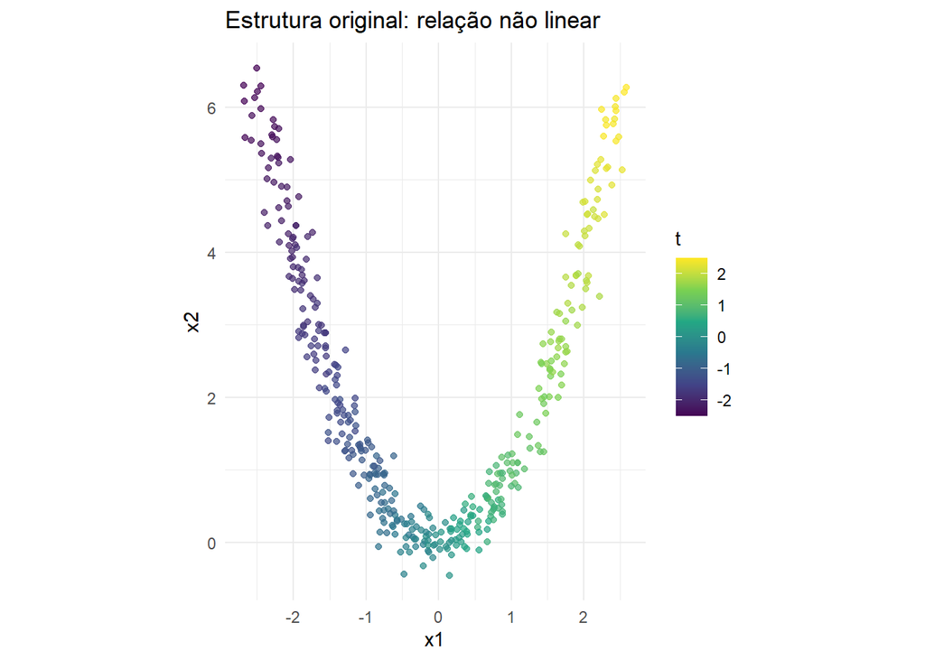

```r
set.seed(335)
n <- 400
t <- runif(n, -2.5, 2.5)

x1 <- t + rnorm(n, sd = 0.12)
x2 <- t^2 + rnorm(n, sd = 0.18)
X <- cbind(
  x1 = x1, x2 = x2,
  x3 = x1 + rnorm(n, sd = 0.15),
  x4 = -x1 + rnorm(n, sd = 0.20),
  x5 = x2 + rnorm(n, sd = 0.20),
  x6 = 0.7*x2 + rnorm(n, sd = 0.20),
  x7 = rnorm(n), x8 = rnorm(n),
  x9 = rnorm(n), x10 = rnorm(n)
)

# t é conhecido apenas por se tratar de uma simulação.
# Não é utilizado para ajustar os métodos.
X_pad <- scale(X)

plot(ggplot(data.frame(x1, x2, t), aes(x1, x2, color = t)) +
       geom_point(alpha = 0.7) +
       scale_color_viridis_c() +
       coord_equal() +
       theme_minimal() +
       labs(title = "Estrutura original: relação não linear"))
```

A forma parabólica indica que a estrutura pode ser descrita por uma coordenada latente, embora não esteja alinhada a uma reta no plano original.

# Diagnóstico: redundância e escala

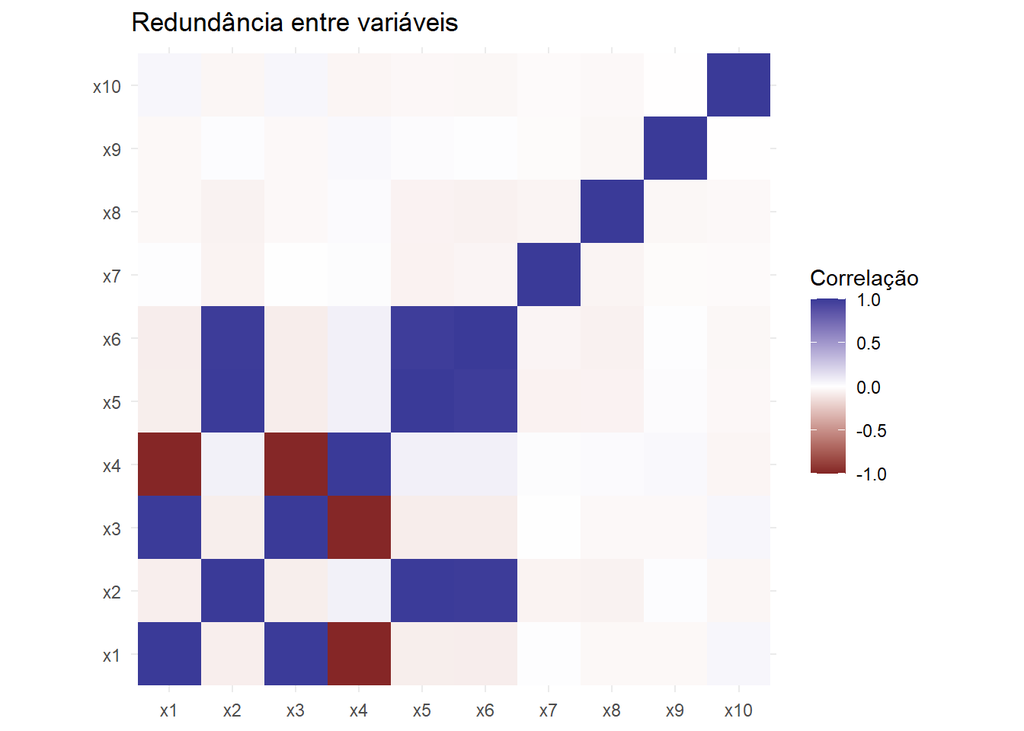

```r
cor_mat <- cor(X)
cor_long <- as.data.frame(as.table(cor_mat))

ggplot(cor_long, aes(Var1, Var2, fill = Freq)) +
  geom_tile() +
  coord_equal() +
  scale_fill_gradient2(limits = c(-1, 1)) +
  labs(x = NULL, y = NULL, fill = "Correlação",
       title = "Redundância entre variáveis") +
  theme_minimal()
```

Correlação elevada indica redundância **linear**, mas não resume todas as dependências possíveis. A padronização evita que variáveis com unidades maiores dominem as análises por escala.

# PCA: representação linear

A PCA procura direções ortogonais que maximizam a variância projetada. A transformação é linear, portanto não desenrola automaticamente uma variedade curva.

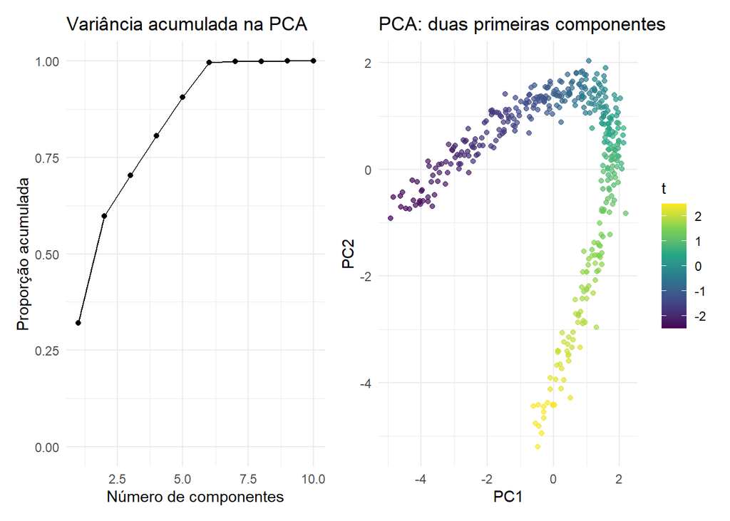

```r
pca <- prcomp(X_pad, center = FALSE, scale. = FALSE)
var_exp <- pca$sdev^2 / sum(pca$sdev^2)

p_var <- ggplot(data.frame(
  componente = seq_along(var_exp),
  acumulada = cumsum(var_exp)
), aes(componente, acumulada)) +
  geom_line() + geom_point() +
  scale_y_continuous(limits = c(0, 1)) +
  labs(title = "Variância acumulada na PCA",
       x = "Número de componentes", y = "Proporção acumulada") +
  theme_minimal()

p_scores <- ggplot(data.frame(
  PC1 = pca$x[, 1], PC2 = pca$x[, 2], t = t
), aes(PC1, PC2, color = t)) +
  geom_point(alpha = 0.7) +
  scale_color_viridis_c() +
  labs(title = "PCA: duas primeiras componentes") +
  theme_minimal()

p_var + p_scores
```

**Interpretação:** a variância explicada mede a informação retida segundo um critério quadrático linear; não mede diretamente preservação de vizinhanças nem capacidade de distinguir classes.

# Kernel PCA: representação não linear

O kernel RBF calcula similaridades que dependem da distância quadrática entre observações:

$$K(\mathbf x_i,\mathbf x_j)=\exp\{-\sigma\|\mathbf x_i-\mathbf x_j\|^2\}$$

O parâmetro `sigma` controla a escala de similaridade. Não existe valor universalmente ótimo; os resultados dependem dos dados e do objetivo da representação.

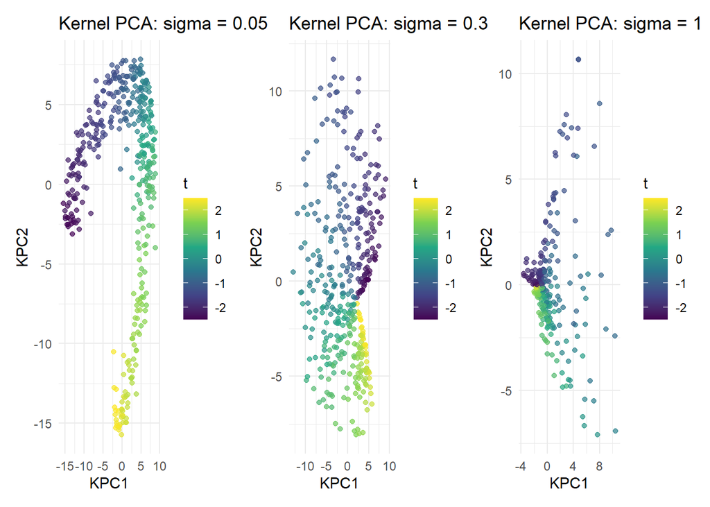

```r
plot_kpca <- function(sigma) {
  ajuste <- kernlab::kpca(
    ~ ., data = as.data.frame(X_pad),
    kernel = "rbfdot", kpar = list(sigma = sigma),
    features = 2
  )
  coord <- as.data.frame(kernlab::rotated(ajuste))
  names(coord)[1:2] <- c("KPC1", "KPC2")
  coord$t <- t
  ggplot(coord, aes(KPC1, KPC2, color = t)) +
    geom_point(alpha = 0.7, size = 1.5) +
    scale_color_viridis_c() +
    labs(title = paste0("Kernel PCA: sigma = ", sigma)) +
    theme_minimal()
}

plot_kpca(0.05) + plot_kpca(0.3) + plot_kpca(1)
```

**Como interpretar:** compare a continuidade da representação e sua sensibilidade a `sigma`. A coloração por `t` é apenas um recurso de diagnóstico disponível porque conhecemos o mecanismo gerador da simulação. **O algoritmo não recebeu `t` no ajuste.**

# Projeções aleatórias: outra finalidade

Diferentemente da PCA, uma projeção aleatória não escolhe direções que maximizem a variância dos dados. Seu interesse principal é reduzir a dimensão com controle probabilístico da distorção das distâncias.

Para $\mathbf R\in\mathbb R^{p\times k}$, utilizamos:

$$\mathbf Z=\mathbf X\mathbf R, \qquad
r_{ij}\overset{\mathrm{iid}}{\sim}N(0,1/k)$$

Com essa normalização, para um par fixo de observações, a distância quadrática é preservada **em esperança** sobre as matrizes aleatórias.

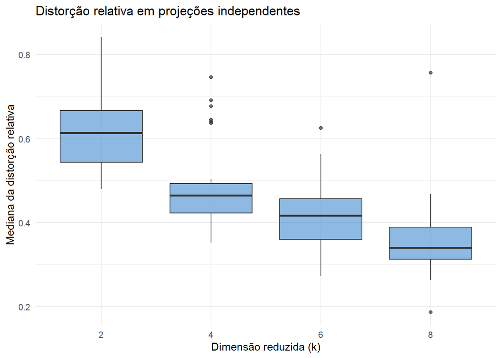

```r
projetar <- function(X, k) {
  R <- matrix(rnorm(ncol(X) * k, sd = 1/sqrt(k)),
              nrow = ncol(X), ncol = k)
  X %*% R
}

# Para evitar problemas de memória, avaliamos uma amostra fixa de pares.
set.seed(335)
pares <- cbind(
  sample(seq_len(nrow(X_pad)), 1500, replace = TRUE),
  sample(seq_len(nrow(X_pad)), 1500, replace = TRUE)
)
pares <- pares[pares[, 1] != pares[, 2], , drop = FALSE]

dist2_pares <- function(M, pares) {
  rowSums((M[pares[, 1], , drop = FALSE] -
           M[pares[, 2], , drop = FALSE])^2)
}

d2_orig <- dist2_pares(X_pad, pares)
stopifnot(all(d2_orig > 0))

set.seed(335)
resultados <- do.call(rbind, lapply(c(2, 4, 6, 8), function(k) {
  do.call(rbind, lapply(seq_len(30), function(rep) {
    Z <- projetar(X_pad, k)
    d2_proj <- dist2_pares(Z, pares)
    data.frame(k = k, repeticao = rep,
               distorcao_mediana = median(abs(d2_proj - d2_orig) / d2_orig),
               distorcao_maxima = max(abs(d2_proj - d2_orig) / d2_orig))
  }))
}))

ggplot(resultados, aes(factor(k), distorcao_mediana)) +
  geom_boxplot(fill = "#5B9BD5", alpha = 0.7) +
  labs(title = "Distorção relativa em projeções independentes",
       x = "Dimensão reduzida (k)",
       y = "Mediana da distorção relativa") +
  theme_minimal()
```

**Interpretação:** a variabilidade entre repetições é esperada. Aumentar `k` tende a melhorar a concentração das distâncias projetadas em torno das originais. Entretanto, uma projeção específica não garante distorção pequena para todos os pares.

# Projeção esparsa de Achlioptas

Uma alternativa usa elementos discretos com muitos zeros:

$$r_{ij}=\sqrt{3/k}\begin{cases}
+1,&\text{com probabilidade }1/6,\\
0,&\text{com probabilidade }2/3,\\
-1,&\text{com probabilidade }1/6
\end{cases}$$

```r
projetar_esparsa <- function(X, k) {
  R <- matrix(
    sample(c(-1, 0, 1), ncol(X)*k, replace = TRUE,
           prob = c(1/6, 2/3, 1/6)),
    nrow = ncol(X), ncol = k
  ) * sqrt(3/k)
  X %*% R
}

set.seed(335)
Z_esparsa <- projetar_esparsa(X_pad, k = 5)
dim(Z_esparsa)
```

```
[1] 400   5
```

A vantagem potencial é computacional: os zeros podem ser explorados por implementações eficientes de álgebra esparsa. A igualdade da distância quadrática **em esperança** permanece válida para essa normalização.

# Análise de agrupamento: três perspectivas

A redução de dimensionalidade **constrói novas coordenadas**. Já a análise de agrupamento procura **formar conjuntos de observações semelhantes**, sem usar rótulos conhecidos. Os dois objetivos podem ser combinados, mas não são equivalentes.

Para comparar os métodos em uma geometria na qual a diferença entre eles seja visível, utilizaremos uma **segunda simulação independente**, com dois anéis concêntricos.

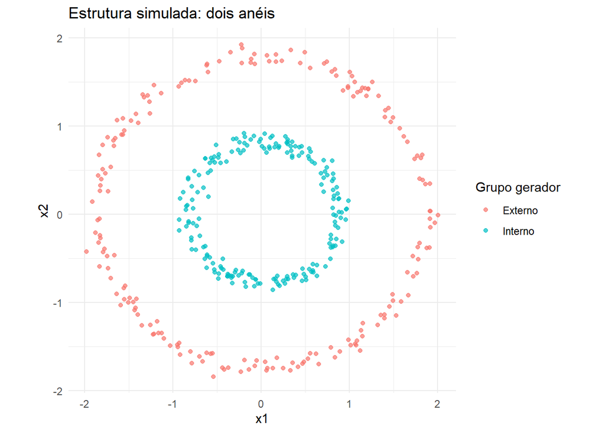

```r
set.seed(3358)
n_an <- 400
anel <- rep(c("Interno", "Externo"), each = n_an/2)
ang <- runif(n_an, 0, 2*pi)
rad <- rep(c(1, 2.2), each = n_an/2) + rnorm(n_an, sd = 0.08)
X_an <- cbind(x1 = rad*cos(ang), x2 = rad*sin(ang))
X_an <- scale(X_an)

dados_an <- data.frame(X_an, anel = anel)
ggplot(dados_an, aes(x1, x2, color = anel)) +
  geom_point(alpha = 0.7) + coord_equal() + theme_minimal() +
  labs(title = "Estrutura simulada: dois anéis", color = "Grupo gerador")
```

A variável `anel` serve apenas para mostrar a estrutura conhecida da simulação. **Ela não entra nos algoritmos nem na escolha de seus parâmetros.**

## K-médias: proximidade aos centróides

O k-médias procura minimizar a soma de quadrados dentro dos grupos:

$$\sum_{g=1}^{K}\sum_{i\in C_g}\|\mathbf x_i-\boldsymbol\mu_g\|^2$$

Como cada observação é atribuída ao centróide mais próximo, o método tende a favorecer regiões convexas e pode dividir os anéis em setores, em vez de recuperar a estrutura radial.

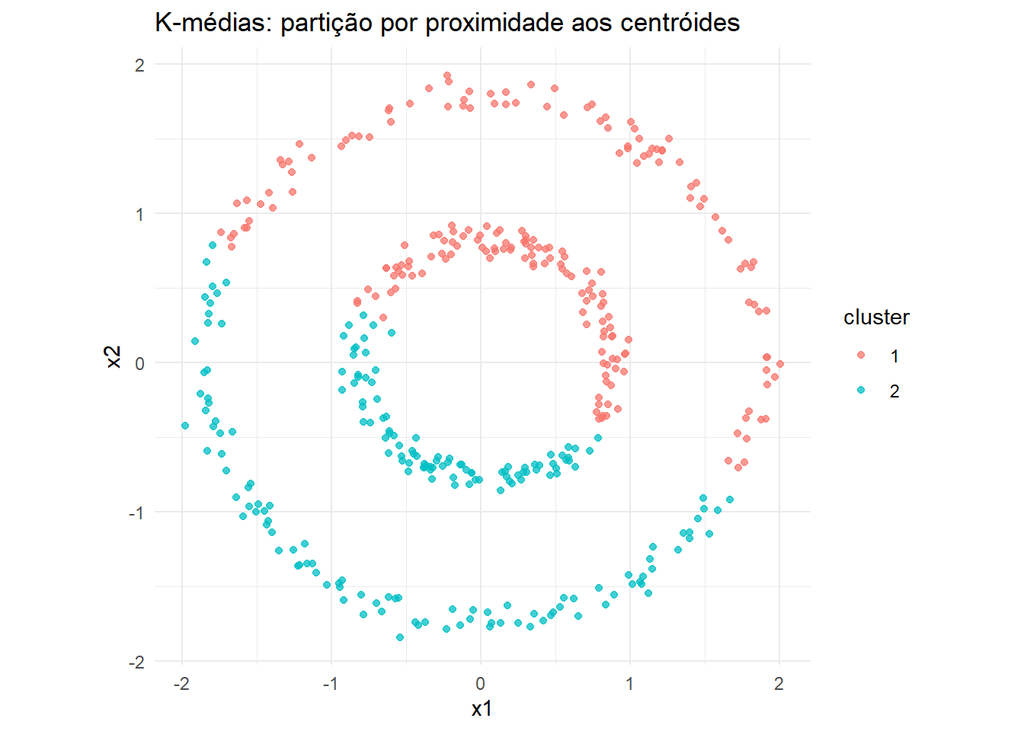

```r
set.seed(335)
km <- kmeans(X_an, centers = 2, nstart = 30)

ggplot(data.frame(X_an, cluster = factor(km$cluster)),
       aes(x1, x2, color = cluster)) +
  geom_point(alpha = 0.75) + coord_equal() + theme_minimal() +
  labs(title = "K-médias: partição por proximidade aos centróides")
```

Uma forma de investigar $K$ sem rótulos é o gráfico da soma de quadrados dentro dos grupos:

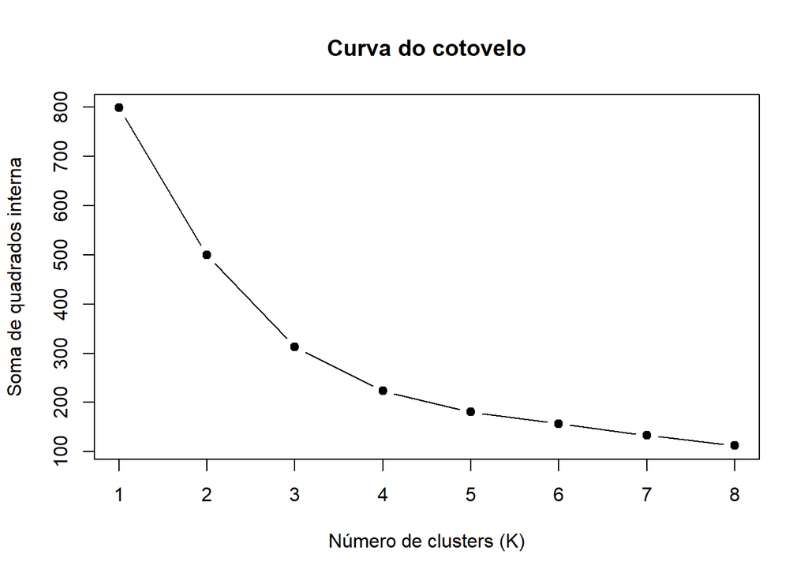

```r
set.seed(335)
wss <- sapply(1:8, function(K) kmeans(X_an, centers = K, nstart = 20)$tot.withinss)
plot(1:8, wss, type = "b", pch = 19,
     xlab = "Número de clusters (K)", ylab = "Soma de quadrados interna",
     main = "Curva do cotovelo")
```

A curva do cotovelo é uma **heurística**, não uma regra que garanta o número correto de grupos.

## Agrupamento hierárquico: distâncias e ligações

O agrupamento hierárquico aglomerativo começa com cada observação isolada e funde grupos sucessivamente. A sequência de fusões depende da métrica e do critério de ligação.

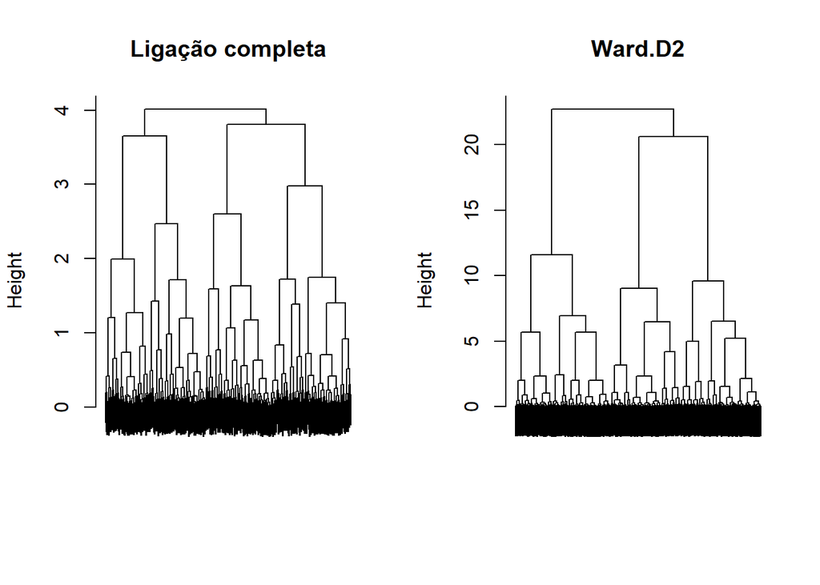

```r
d_an <- dist(X_an, method = "euclidean")
hc_complete <- hclust(d_an, method = "complete")
hc_ward <- hclust(d_an, method = "ward.D2")

par(mfrow = c(1, 2))
plot(hc_complete, labels = FALSE, main = "Ligação completa", xlab = "", sub = "")
plot(hc_ward, labels = FALSE, main = "Ward.D2", xlab = "", sub = "")
```

```r
par(mfrow = c(1, 1))

cl_hier <- cutree(hc_complete, k = 2)
table(cl_hier)
```

```
cl_hier
  1   2
163 237
```

O dendrograma descreve uma hierarquia de fusões; um corte em $K=2$ produz uma partição. **O agrupamento hierárquico convencional também não garante a recuperação de anéis**, especialmente com certas ligações.

## Agrupamento espectral: similaridades e geometria não convexa

O agrupamento espectral constrói uma representação a partir de similaridades entre observações. Com um kernel RBF, observações próximas recebem similaridades maiores:

$$s(\mathbf x_i,\mathbf x_j)=\exp\{-\sigma\|\mathbf x_i-\mathbf x_j\|^2\}$$

Em seguida, a estrutura espectral do grafo de similaridades orienta a formação dos grupos. O resultado depende da escala do kernel e da conectividade induzida pelas similaridades.

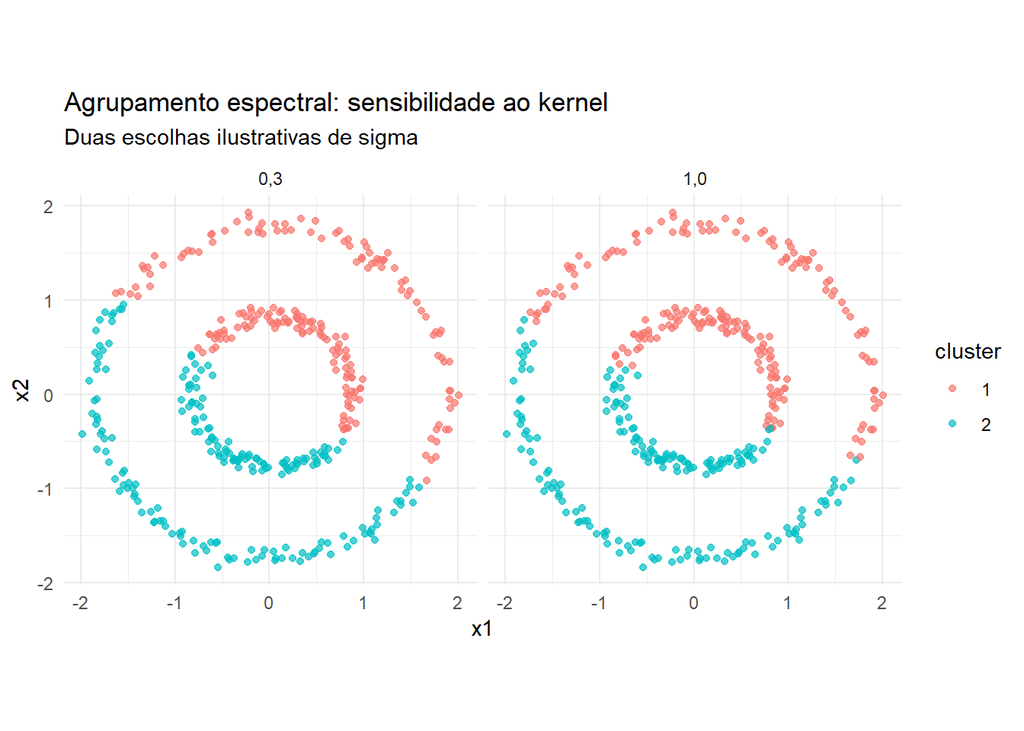

```r
set.seed(335)
sp1 <- kernlab::specc(X_an, centers = 2,
                      kernel = "rbfdot", kpar = list(sigma = 0.3))
set.seed(335)
sp2 <- kernlab::specc(X_an, centers = 2,
                      kernel = "rbfdot", kpar = list(sigma = 1.0))

res_sp <- rbind(
  data.frame(X_an, sigma = "0,3", cluster = factor(as.integer(sp1))),
  data.frame(X_an, sigma = "1,0", cluster = factor(as.integer(sp2)))
)

ggplot(res_sp, aes(x1, x2, color = cluster)) +
  geom_point(alpha = 0.7) + coord_equal() +
  facet_wrap(~sigma) + theme_minimal() +
  labs(title = "Agrupamento espectral: sensibilidade ao kernel",
       subtitle = "Duas escolhas ilustrativas de sigma")
```

**Interpretação:** o agrupamento espectral pode identificar conjuntos não convexos quando a matriz de similaridades representa adequadamente sua estrutura. Entretanto, isso **não é garantido para todo kernel ou parâmetro**.

## Avaliação interna e comparação posterior com os grupos simulados

A **silhueta média** resume, para cada observação, a relação entre a distância média ao próprio grupo e a distância ao grupo alternativo mais próximo. É uma medida interna, calculada sem conhecer `anel`.

```r
# O pacote cluster acompanha instalações usuais do R.
library(cluster)

sil_media <- function(rotulos, d) {
  mean(cluster::silhouette(as.integer(factor(rotulos)), d)[, "sil_width"])
}

comparacao <- data.frame(
  metodo = c("K-médias", "Hierárquico (complete)", "Espectral (sigma=0,3)"),
  silhueta = c(
    sil_media(km$cluster, d_an),
    sil_media(cl_hier, d_an),
    sil_media(as.integer(sp1), d_an)
  )
)
print(comparacao)
```

```
                  metodo  silhueta
1               K-médias 0.3619380
2 Hierárquico (complete) 0.2950384
3  Espectral (sigma=0,3) 0.3611888
```

A silhueta euclidiana pode favorecer partições compactas mesmo quando os grupos verdadeiros são não convexos. Portanto, **uma silhueta maior não significa necessariamente melhor recuperação dos anéis**.

Agora, **somente depois do ajuste**, podemos usar os rótulos geradores para interpretar a concordância externa:

```r
cat("K-médias versus anéis:\n")
```

```
K-médias versus anéis:
```

```r
print(table(Estimado = km$cluster, Gerador = anel))
```

```
        Gerador
Estimado Externo Interno
       1      97     109
       2     103      91
```

```r
cat("Espectral versus anéis:\n")
```

```
Espectral versus anéis:
```

```r
print(table(Estimado = as.integer(sp1), Gerador = anel))
```

```
        Gerador
Estimado Externo Interno
       1      91     106
       2     109      94
```

Os números dos clusters são arbitrários: uma troca entre os nomes “1” e “2” não altera o agrupamento. Na A4, será necessário comparar os três métodos sobre a base da atividade, que tem **outra geometria** e **três grupos**.

# Síntese comparativa

| Método | Ideia principal | O que prioriza | Limitação relevante |
| --- | --- | --- | --- |
| PCA | Projeções lineares ajustadas aos dados | Variância projetada | Não captura diretamente geometria não linear |
| Kernel PCA | Componentes em espaço de características definido por kernel | Estrutura de similaridades | Sensível ao kernel e a seus parâmetros |
| Projeção aleatória | Projeções independentes dos dados | Preservação aproximada de distâncias | Resultado varia com a matriz e com `k` |
| K-médias | Minimização da dispersão intragrupos | Grupos próximos a centróides | Sensível à inicialização e à geometria |
| Hierárquico | Fusões sucessivas baseadas em distâncias | Organização em dendrograma | Sensível à métrica e à ligação |
| Espectral | Estrutura de similaridades | Agrupamentos potencialmente não convexos | Sensível ao grafo/kernel e seus parâmetros |